# Data Wrangling Project

#### All scores are correctly identified in the downloaded data, there are now only 2 which are not genuine scores...

```python
df_dogdata.loc[df_dogdata.tweet_id.isin([832088576586297345,810984652412424192]),
               ["tweet_id","text", "rating_numerator", "rating_denominator"]]
```

|  | tweet_id | text | rating_numerator | rating_denominator |
| --- | --- | --- | --- | --- |
| 328 | 832088576586297345 | @docmisterio account started on 11/15/15 | 15.0 | 15 |
| 499 | 810984652412424192 | Meet Sam. She smiles 24/7 &amp; secretly aspires to be a reindeer. \nKeep Sam smiling by clicking and sharing this link:\nhttps://t.co/98tB8y7y7t https://t.co/LouL5vdvxx | 24.0 | 7 |

```python
df_dogdata.loc[df_dogdata.tweet_id.isin([832088576586297345,810984652412424192]),
               ["rating_numerator","rating_denominator"]] = 0, 0
```

```python
df_dogdata.loc[df_dogdata.tweet_id.isin([832088576586297345,810984652412424192]),
               ["tweet_id","text", "rating_numerator", "rating_denominator"]]
```

|  | tweet_id | text | rating_numerator | rating_denominator |
| --- | --- | --- | --- | --- |
| 328 | 832088576586297345 | @docmisterio account started on 11/15/15 | 0.0 | 0 |
| 499 | 810984652412424192 | Meet Sam. She smiles 24/7 &amp; secretly aspires to be a reindeer. \nKeep Sam smiling by clicking and sharing this link:\nhttps://t.co/98tB8y7y7t https://t.co/LouL5vdvxx | 0.0 | 0 |

### Check retweets

```python
df_dogdata.loc[df_dogdata.retweeted_status_id.notnull()].head()
```

[output not shown]

```python
len(df_dogdata.loc[df_dogdata.retweeted_status_id.notnull()])
```

```
179
```

There are a couple of records in the original data that have `RT` at the beginning of the string, but are not marked as retweets in the retweeted_status_id (i.e. are `NaN`). Check to see if we have anything for these in this dataset.

```python
testrt = []
for rt in df.loc[(df.text.str[:2]=="RT") & (df.retweeted_status_id.isnull()),["tweet_id"]].values:
    testrt.append(*rt)
testrt
```

```
[708400866336894977, 675489971617296384]
```

```python
df_dogdata.loc[df_dogdata.tweet_id.isin(testrt)]
```

|  | tweet_id | retweet_count | favorite_count | rating_numerator | rating_denominator | text | urls | expanded_urls | retweeted_status_id | retweeted_status_user_id | retweeted_status_timestamp |
| --- | --- | --- | --- | --- | --- | --- | --- | --- | --- | --- | --- |
| 1262 | 708400866336894977 | 10027 | 15931 | 12.0 | 10 | RT if you are as ready for summer as this pup is 12/10 https://t.co/xdNNEZdGJY | https://t.co/xdNNEZdGJY | None | NaN | None | NaT |
| 1835 | 675489971617296384 | 579 | 1266 | 10.0 | 10 | RT until we find this dog. Clearly a cool dog (front leg relaxed out window). Looks to be a superb driver. 10/10 https://t.co/MnTrKaQ8Wn | https://t.co/MnTrKaQ8Wn | https://twitter.com/dog_rates/status/675489971617296384/photo/1 | NaN | None | NaT |

**No, they are not retweets according to their retweet data, despite the indicator in their text**

```python
df_dogdata.to_pickle("df_dogdata.pkl")
```

## Summary of processing original tweets

- Records have been obtained by loading tweets using the Tweepy API
- Missing records were obtained from the supplied `json` file, only 2 records were not obtained
- **Retweet count** and **favorite count** are now available
- **Scores** have been correctly obtained, so these can be used to correct the original scores
- **Retweet status** and **image urls** were also been included, to verify and possibly correct original data (none needed)

## 3. Data assessment of image predictions file

```python
df_image_preds.head()
```

|  | tweet_id | jpg_url | img_num | p1 | p1_conf | p1_dog | p2 | p2_conf | p2_dog | p3 | p3_conf | p3_dog |
| --- | --- | --- | --- | --- | --- | --- | --- | --- | --- | --- | --- | --- |
| 0 | 666020888022790149 | https://pbs.twimg.com/media/CT4udn0WwAA0aMy.jpg | 1 | Welsh_springer_spaniel | 0.465074 | True | collie | 0.156665 | True | Shetland_sheepdog | 0.061428 | True |
| 1 | 666029285002620928 | https://pbs.twimg.com/media/CT42GRgUYAA5iDo.jpg | 1 | redbone | 0.506826 | True | miniature_pinscher | 0.074192 | True | Rhodesian_ridgeback | 0.072010 | True |
| 2 | 666033412701032449 | https://pbs.twimg.com/media/CT4521TWwAEvMyu.jpg | 1 | German_shepherd | 0.596461 | True | malinois | 0.138584 | True | bloodhound | 0.116197 | True |
| 3 | 666044226329800704 | https://pbs.twimg.com/media/CT5Dr8HUEAA-lEu.jpg | 1 | Rhodesian_ridgeback | 0.408143 | True | redbone | 0.360687 | True | miniature_pinscher | 0.222752 | True |
| 4 | 666049248165822465 | https://pbs.twimg.com/media/CT5IQmsXIAAKY4A.jpg | 1 | miniature_pinscher | 0.560311 | True | Rottweiler | 0.243682 | True | Doberman | 0.154629 | True |

```python
df_image_preds.loc[df_image_preds.img_num > 1].head()
```

|  | tweet_id | jpg_url | img_num | p1 | p1_conf | p1_dog | p2 | p2_conf | p2_dog | p3 | p3_conf | p3_dog |
| --- | --- | --- | --- | --- | --- | --- | --- | --- | --- | --- | --- | --- |
| 144 | 668623201287675904 | https://pbs.twimg.com/media/CUdtP1xUYAIeBnE.jpg | 4 | Chihuahua | 0.708163 | True | Pomeranian | 0.091372 | True | titi | 0.067325 | False |
| 312 | 671547767500775424 | https://pbs.twimg.com/media/CVHRIiqWEAAj98K.jpg | 2 | Loafer | 0.255088 | False | platypus | 0.090019 | False | cowboy_boot | 0.066536 | False |
| 315 | 671735591348891648 | https://pbs.twimg.com/media/CVJ79MzW4AEpTom.jpg | 2 | stone_wall | 0.271121 | False | Irish_wolfhound | 0.063078 | True | poncho | 0.048226 | False |
| 319 | 671768281401958400 | https://pbs.twimg.com/media/CVKZsHtWwAA6gPj.jpg | 2 | Chihuahua | 0.500373 | True | French_bulldog | 0.112796 | True | Italian_greyhound | 0.062893 | True |
| 345 | 672272411274932228 | https://pbs.twimg.com/media/CVRkLuJWUAAhhYp.jpg | 2 | pug | 0.914685 | True | Norwegian_elkhound | 0.014982 | True | Siamese_cat | 0.009221 | False |

### Look at some images...

```python
df_image_preds.loc[df_image_preds.tweet_id == 668623201287675904]
```

|  | tweet_id | jpg_url | img_num | p1 | p1_conf | p1_dog | p2 | p2_conf | p2_dog | p3 | p3_conf | p3_dog |
| --- | --- | --- | --- | --- | --- | --- | --- | --- | --- | --- | --- | --- |
| 144 | 668623201287675904 | https://pbs.twimg.com/media/CUdtP1xUYAIeBnE.jpg | 4 | Chihuahua | 0.708163 | True | Pomeranian | 0.091372 | True | titi | 0.067325 | False |

[figure not shown]

```python
df.loc[df.tweet_id == 668623201287675904]
```

|  | tweet_id | in_reply_to_status_id | in_reply_to_user_id | timestamp | source | text | retweeted_status_id | retweeted_status_user_id | retweeted_status_timestamp | expanded_urls | rating_numerator | rating_denominator | name | doggo | floofer | pupper | puppo |
| --- | --- | --- | --- | --- | --- | --- | --- | --- | --- | --- | --- | --- | --- | --- | --- | --- | --- |
| 2209 | 668623201287675904 | NaN | NaN | 2015-11-23 02:52:48 +0000 | <a href="http://twitter.com/download/iphone" rel="nofollow">Twitter for iPhone</a> | This is Jomathan. He is not thrilled about the length of the grass. 10/10 https://t.co/TIhVKEIPqj | NaN | NaN | NaN | https://twitter.com/dog_rates/status/668623201287675904/photo/1,https://twitter.com/dog_rates/status/668623201287675904/photo/1,https://twitter.com/dog_rates/status/668623201287675904/photo/1,https://… | 10 | 10 | Jomathan | None | None | None | None |

**Note:** - the small image linked in the predictions above is actually present in the white rectangle below when it is clicked on

[figure not shown]

```python
df_image_preds.loc[df_image_preds.tweet_id == 671547767500775424]
```

|  | tweet_id | jpg_url | img_num | p1 | p1_conf | p1_dog | p2 | p2_conf | p2_dog | p3 | p3_conf | p3_dog |
| --- | --- | --- | --- | --- | --- | --- | --- | --- | --- | --- | --- | --- |
| 312 | 671547767500775424 | https://pbs.twimg.com/media/CVHRIiqWEAAj98K.jpg | 2 | Loafer | 0.255088 | False | platypus | 0.090019 | False | cowboy_boot | 0.066536 | False |

[figure not shown]

```python
df.loc[df.tweet_id == 671547767500775424]
```

|  | tweet_id | in_reply_to_status_id | in_reply_to_user_id | timestamp | source | text | retweeted_status_id | retweeted_status_user_id | retweeted_status_timestamp | expanded_urls | rating_numerator | rating_denominator | name | doggo | floofer | pupper | puppo |
| --- | --- | --- | --- | --- | --- | --- | --- | --- | --- | --- | --- | --- | --- | --- | --- | --- | --- |
| 2039 | 671547767500775424 | NaN | NaN | 2015-12-01 04:33:59 +0000 | <a href="http://twitter.com/download/iphone" rel="nofollow">Twitter for iPhone</a> | This is Marley. She chews shoes then feels extremely guilty about it and refuses to look at them. 10/10 https://t.co/f99MV0htAV | NaN | NaN | NaN | https://twitter.com/dog_rates/status/671547767500775424/photo/1,https://twitter.com/dog_rates/status/671547767500775424/photo/1 | 10 | 10 | Marley | None | None | None | None |

[figure not shown]

```python
df_image_preds.loc[df_image_preds.tweet_id == 671735591348891648]
```

|  | tweet_id | jpg_url | img_num | p1 | p1_conf | p1_dog | p2 | p2_conf | p2_dog | p3 | p3_conf | p3_dog |
| --- | --- | --- | --- | --- | --- | --- | --- | --- | --- | --- | --- | --- |
| 315 | 671735591348891648 | https://pbs.twimg.com/media/CVJ79MzW4AEpTom.jpg | 2 | stone_wall | 0.271121 | False | Irish_wolfhound | 0.063078 | True | poncho | 0.048226 | False |

[figure not shown]

```python
df.loc[df.tweet_id == 671735591348891648]
```

|  | tweet_id | in_reply_to_status_id | in_reply_to_user_id | timestamp | source | text | retweeted_status_id | retweeted_status_user_id | retweeted_status_timestamp | expanded_urls | rating_numerator | rating_denominator | name | doggo | floofer | pupper | puppo |
| --- | --- | --- | --- | --- | --- | --- | --- | --- | --- | --- | --- | --- | --- | --- | --- | --- | --- |
| 2035 | 671735591348891648 | NaN | NaN | 2015-12-01 17:00:19 +0000 | <a href="http://twitter.com/download/iphone" rel="nofollow">Twitter for iPhone</a> | This is Oscar. He's ready for Christmas. 11/10 https://t.co/TON0Irzgwr | NaN | NaN | NaN | https://twitter.com/dog_rates/status/671735591348891648/photo/1,https://twitter.com/dog_rates/status/671735591348891648/photo/1,https://twitter.com/dog_rates/status/671735591348891648/photo/1,https://… | 11 | 10 | Oscar | None | None | None | None |

[figure not shown]

### These tweets could not be found in the images data

See https://stackoverflow.com/questions/26535563/querying-for-nan-and-other-names-in-pandas for hack to remove NaN from the query below

```python
len(df.query('tweet_id in @df_image_preds.tweet_id')), \
len(df.query('(tweet_id not in @df_image_preds.tweet_id) and (expanded_urls == expanded_urls)'))
```

```
(2075, 222)
```

```python
df.query('(tweet_id not in @df_image_preds.tweet_id) and (expanded_urls == expanded_urls)')\
[["tweet_id", "text", "name", "expanded_urls", "rating_numerator", "rating_denominator"]].head()
```

|  | tweet_id | text | name | expanded_urls | rating_numerator | rating_denominator |
| --- | --- | --- | --- | --- | --- | --- |
| 32 | 886054160059072513 | RT @Athletics: 12/10 #BATP https://t.co/WxwJmvjfxo | None | https://twitter.com/dog_rates/status/886053434075471873,https://twitter.com/dog_rates/status/886053434075471873 | 12 | 10 |
| 35 | 885518971528720385 | I have a new hero and his name is Howard. 14/10 https://t.co/gzLHboL7Sk | None | https://twitter.com/4bonds2carbon/status/885517367337512960 | 14 | 10 |
| 42 | 884247878851493888 | OMG HE DIDN'T MEAN TO HE WAS JUST TRYING A LITTLE BARKOUR HE'S SUPER SORRY 13/10 WOULD FORGIVE IMMEDIATE https://t.co/uF3pQ8Wubj | None | https://twitter.com/kaijohnson_19/status/883965650754039809 | 13 | 10 |
| 68 | 879130579576475649 | RT @dog_rates: This is Emmy. She was adopted today. Massive round of pupplause for Emmy and her new family. 14/10 for all involved https://… | Emmy | https://twitter.com/dog_rates/status/878057613040115712/photo/1,https://twitter.com/dog_rates/status/878057613040115712/photo/1 | 14 | 10 |
| 72 | 878604707211726852 | Martha is stunning how h*ckin dare you. 13/10 https://t.co/9uABQXgjwa | None | https://twitter.com/bbcworld/status/878599868507402241 | 13 | 10 |

## Summary of the image predictions file data assessment

- Not all tweets are represented
- Some of the classification is inaccurate, but generally it does well
- It's interesting that non-dogs have also been classified, perhaps this has led to dogs being missed due to a stronger non-dog image match
- The data structure has some redundancy, however its a useful format for quickly scanning - perhaps a tidiness issue?
- The `img_num` column does not always count image numbers accurately
  - Besides which, only one image is used even if there are multiple images available

# Data Quality and Tidiness Summary

## Data Quality Issues

- `doggo`, `floofer`, `pupper`, `puppo` and `name` contain the string "None" instead of a blank or NaN
- 338 tweets have text containing a `doggo`, `floofer`, `pupper`, or `puppo` mention but have not been assigned the label
- These tweets mention multiple dog types, but the correct information is singular:
  - 854010172552949760 - s/b doggo only - "shy doggo, but it's actually a Rare Canadian Floofer Owl"
  - 855851453814013952 - s/b puppo only - "a puppo participating ... doggo agenda"
  - 817777686764523521 - s/b pupper only - "Pupper Stops to Catch Snow ... IG: didodoggo"
  - 751583847268179968 - s/b doggo only - "stop sending it pictures that don't even have a doggo or pupper in them"
- Using an integer data type for rating_numerator has corrupted scores with a decimal point
  - 681340665377193984, 883482846933004288, 832215909146226688, 786709082849828864, 778027034220126208, 680494726643068929
- There may be tweets that don't actually have a score, or are scored incorrectly
  - 835246439529840640, 832088576586297345, 810984652412424192, 775096608509886464, 740373189193256964, 722974582966214656, 716439118184652801, 682962037429899265, 666287406224695296
- There are tweets with more than one score (aside from those that can be corrected)
  - 802624713319034886, 777684233540206592, 763167063695355904, 714258258790387713, 703356393781329922, 695064344191721472, 694352839993344000, 691483041324204033, 690400367696297985, 677314812125323265, 676191832485810177, 674737130913071104, 674646392044941312, 673295268553605120, 672248013293752320, 671154572044468225, 670434127938719744, 669037058363662336, 668537837512433665, 667544320556335104, 667491009379606528
- The `names` field has incorrect values
  - "None" instead of a blank or NaN
  - a, actually, all, an, by, getting, his, incredibly, infuriating, just, life, light, mad, my, not, officially, old, one, quite, space, such, the, this, unacceptable, very
- Some `name` values are missing
  - There may be some altogether missing
  - Others where more than one name is mentioned in the text
- There can be duplicates
  - Duplicates in the expanded_urls column
- There are many without any url, therefore they will not be able to be able to be located, and any associated image won't be found
- There are 181 retweets - according to the project specification these are not wanted

### Further data observations

- These are not data quality issues, but relate to the project goal of having images of dogs
- a score of zero may relate to seeing no dog, or a plagiarized image
  - 835152434251116546, 746906459439529985
- a score of one can also indicate no dog
  - 670783437142401025, 667549055577362432, 798576900688019456, 666104133288665088
- and even a high score may have no dog image in it (Kelvin)
  - 840696689258311684

## Data Tidiness Issues

### Main table

- **dog types:** `doggo`, `floofer`, `pupper` and `puppo` columns
  - they could become values in a separate table of dog types
  - or, they could contain a boolean for a mention, or a count of mentions - rather than repeating the column name in the data
  - or, most suitably, become **one column containing a comma separated list of the dog types**
- **`name`:** column
  - there can be no name, or more than one name so according to tidiness rules this is also a candidate for a separate table
  - however, since multiple names are rare and `name` is not a categorical value, **one column containing a comma separated list** is a suitable solution
- **Scores columns** - `rating_numerator` and `rating_denominator`
  - there is more than one score in some tweets, so the scores columns are likewise candidates for a separate table

### Images table

- The repeating use of columns to describe the top three predictions could be considered an issue
- However, to split this into separate rows in a tidy format would require two tables
  - one for the tweets_id and image url - with a key ID, and one for the predictions linked to the key ID
  - however, we could ensure that the image url always exists in the original data, then link to that directly
  - a disadvantage of splitting it into tables would be that we would lose the ability to quickly scan a single row for the predictions
  - these can be **combined back into the main table** as a set of predictions columns

# Data Cleaning

### Start with a copy of the original data

```python
df_clean = df.copy()
```

```python
df_clean.info()
```

```
<class 'pandas.core.frame.DataFrame'>
RangeIndex: 2356 entries, 0 to 2355
Data columns (total 17 columns):
tweet_id                      2356 non-null int64
in_reply_to_status_id         78 non-null float64
in_reply_to_user_id           78 non-null float64
timestamp                     2356 non-null object
source                        2356 non-null object
text                          2356 non-null object
retweeted_status_id           181 non-null float64
retweeted_status_user_id      181 non-null float64
retweeted_status_timestamp    181 non-null object
expanded_urls                 2297 non-null object
rating_numerator              2356 non-null int64
rating_denominator            2356 non-null int64
name                          2356 non-null object
doggo                         2356 non-null object
floofer                       2356 non-null object
pupper                        2356 non-null object
puppo                         2356 non-null object
dtypes: float64(4), int64(3), object(10)
memory usage: 313.0+ KB
```

## 1. Remove unwanted records

### 1.a Define

- *Only want original ratings (no retweets) that have images*
- *Not all tweets are dog ratings*
- I am interpreting this conservatively as this is open to interpretation
- **Retweets**
  - Retweets will be removed based on their having a non-null `retweeted_status_id`
  - Leaving two that have null in the status id but 'RT' as the first 2 characters of the text
- **Images**
  - A tweet will be considered as likely to have an image if it has a value in `expanded_url`, as then the tweet can be loaded and viewed
  - Rather than, if it has a link to the image predictions table - the instruction does *not* say "that have *image predictions* "
  - There are some that definitely *do not have dog images* so these will be removed - but this is a token effort, a *POC*
    - it would require manual loading and inspecting every tweet to verify them
- **Ratings**
  - After initial records are removed based on retweets and images, ratings will be updated from the corrected ratings
  - Then any remaining that have no valid score and two have been identified that have no genuine dog rating and will be removed

### 1.b Code

#### Remove retweets

```python
len(df_clean), len(df_clean.loc[df_clean.retweeted_status_id.isnull()])
```

```
(2356, 2175)
```

**Take a backup of removed retweets**

```python
df_retweets = df_clean.loc[df_clean.retweeted_status_id.notnull()]
```

```python
len(df_retweets)
```

```
181
```

```python
df_clean = df_clean.loc[df_clean.retweeted_status_id.isnull()].copy()
```

```python
len(df_clean)
```

```
2175
```

#### Remove those without a URL

```python
len(df_clean), len(df_clean.loc[df_clean.expanded_urls.notnull()])
```

```
(2175, 2117)
```

**Take a backup of removed tweets with no URL**

```python
df_no_url = df_clean.loc[df_clean.expanded_urls.isnull()].copy()
```

```python
len(df_no_url)
```

```
58
```

```python
df_clean = df_clean.loc[df_clean.expanded_urls.notnull()].copy()
```

```python
len(df_clean)
```

```
2117
```

#### A score of zero may relate to seeing no dog, or a plagiarized image

- Remove these, to align with the instruction to retain only those with a dog image
- There are others where a low score (or even a high score) may not be a dog image (e.g. a chicken, a person), but I will keep those in the spirit of the Dog Ratings site which celebrates them with a witty caption

```python
df_clean.loc[df_clean.tweet_id.isin([835152434251116546, 746906459439529985]),
             ["text", "rating_numerator", "rating_denominator"]]
```

|  | text | rating_numerator | rating_denominator |
| --- | --- | --- | --- |
| 315 | When you're so blinded by your systematic plagiarism that you forget what day it is. 0/10 https://t.co/YbEJPkg4Ag | 0 | 10 |
| 1016 | PUPDATE: can't see any. Even if I could, I couldn't reach them to pet. 0/10 much disappointment https://t.co/c7WXaB2nqX | 0 | 10 |

```python
df_clean = df_clean.loc[~df_clean.tweet_id.isin([835152434251116546, 746906459439529985])].copy()
```

### 1.c Test

```python
len(df_clean)
```

```
2115
```

## 2. Set index of clean data to the tweet_id for processing

- Makes it more straightforward to use `merge` or `update` with replacement data

```python
df_clean.index
```

```
Int64Index([   0,
               1,
               2,
               3,
               4,
               5,
               6,
               7,
               8,
               9,
            ...
            2346,
            2347,
            2348,
            2349,
            2350,
            2351,
            2352,
            2353,
            2354,
            2355],
           dtype='int64', length=2115)
```

```python
df_clean.set_index('tweet_id', inplace=True, drop=False)
```

```python
df_clean.index
```

```
Int64Index([892420643555336193,
            892177421306343426,
            891815181378084864,
            891689557279858688,
            891327558926688256,
            891087950875897856,
            890971913173991426,
            890729181411237888,
            890609185150312448,
            890240255349198849,
            ...
            666058600524156928,
            666057090499244032,
            666055525042405380,
            666051853826850816,
            666050758794694657,
            666049248165822465,
            666044226329800704,
            666033412701032449,
            666029285002620928,
            666020888022790149],
           dtype='int64', name='tweet_id', length=2115)
```

```python
df_clean.head(1)
```

| tweet_id | tweet_id | in_reply_to_status_id | in_reply_to_user_id | timestamp | source | text | retweeted_status_id | retweeted_status_user_id | retweeted_status_timestamp | expanded_urls | rating_numerator | rating_denominator | name | doggo | floofer | pupper | puppo |
| --- | --- | --- | --- | --- | --- | --- | --- | --- | --- | --- | --- | --- | --- | --- | --- | --- | --- |
| 892420643555336193 | 892420643555336193 | NaN | NaN | 2017-08-01 16:23:56 +0000 | <a href="http://twitter.com/download/iphone" rel="nofollow">Twitter for iPhone</a> | This is Phineas. He's a mystical boy. Only ever appears in the hole of a donut. 13/10 https://t.co/MgUWQ76dJU | NaN | NaN | NaN | https://twitter.com/dog_rates/status/892420643555336193/photo/1 | 13 | 10 | Phineas | None | None | None | None |

## 3. Test conversion of datetime string fields to datetime

### 3.a Define

- Though not strictly needed, it is a check that we have correct data types if they convert correctly...

### 3.b Code

```python
df_test_timestamps = df_clean.copy()
```

```python
df_test_timestamps['timestamp'] = pd.to_datetime(df_test_timestamps['timestamp'])
df_test_timestamps['retweeted_status_timestamp'] = pd.to_datetime(df_test_timestamps['retweeted_status_timestamp'])
```

### 3.c Check

- Timestamps should have been sucessfully converted

```python
df_test_timestamps.info()
```

```
<class 'pandas.core.frame.DataFrame'>
Int64Index: 2115 entries, 892420643555336193 to 666020888022790149
Data columns (total 17 columns):
tweet_id                      2115 non-null int64
in_reply_to_status_id         22 non-null float64
in_reply_to_user_id           22 non-null float64
timestamp                     2115 non-null datetime64[ns, UTC]
source                        2115 non-null object
text                          2115 non-null object
retweeted_status_id           0 non-null float64
retweeted_status_user_id      0 non-null float64
retweeted_status_timestamp    0 non-null datetime64[ns]
expanded_urls                 2115 non-null object
rating_numerator              2115 non-null int64
rating_denominator            2115 non-null int64
name                          2115 non-null object
doggo                         2115 non-null object
floofer                       2115 non-null object
pupper                        2115 non-null object
puppo                         2115 non-null object
dtypes: datetime64[ns, UTC](1), datetime64[ns](1), float64(4), int64(3), object(8)
memory usage: 297.4+ KB
```

## 4. Remove duplicates from the expanded_urls field

### 4.a Define

- Fix any `expanded_urls` with duplicates, as these are not desirable as it makes processing of them more complicated than it should be

```python
print("Tweets with URLs: {}".format(len(df_clean.loc[
     (df_clean.expanded_urls.notna())])))
print("Tweets with potential duplicate URLs: {}".format(len(df_clean.loc[
            (df_clean.expanded_urls.notna()) &
            (df_clean.expanded_urls.str.contains(","))])))
```

```
Tweets with URLs: 2115
Tweets with potential duplicate URLs: 508
```

### 4.b Code

```python
for row in df_clean.loc[(df_dogdata.expanded_urls.notna()) &
                        (df_clean.expanded_urls.str.contains(",")),["tweet_id","expanded_urls"]].itertuples():
    print(row.tweet_id)
    print(row.expanded_urls)
    expurls = row.expanded_urls.split(",")
    correct_urls = set()
    for url in expurls:
        correct_urls.add(url)
    print(len(expurls), "-->", len(correct_urls), ",".join(list(correct_urls)))
    df_clean.loc[row.tweet_id, ["expanded_urls"]] = ",".join(list(correct_urls))
    print(df_clean.loc[row.tweet_id, ["expanded_urls"]])
    print()
```

### 4.c Check

- There should be fewer records with potential duplicates

```python
print("Tweets with URLs: {}".format(len(df_clean.loc[(df_clean.expanded_urls.notna())])))
print("Tweets with potential duplicate URLs: {}".format(len(df_clean.loc[(df_dogdata.expanded_urls.notna()) &\
                                                        (df_clean.expanded_urls.str.contains(","))])))
```

```
Tweets with URLs: 2115
Tweets with potential duplicate URLs: 28
```

## 5. Fix "None" in the name and dog type fields

### 5.a Define

- `name`, `doggo`, `floofer`, `pupper` and `puppo` contain the string "None" instead of a `NaN`

### 5.b Code

```python
df_clean.loc[df_clean.doggo == 'None', ["doggo"]] = None
df_clean.loc[df_clean.floofer == 'None', ["floofer"]] = None
df_clean.loc[df_clean.pupper == 'None', ["pupper"]] = None
df_clean.loc[df_clean.puppo == 'None', ["puppo"]] = None
df_clean.loc[df_clean.name == 'None', ["name"]] = None
```

### 5.c Check

- Should pass the assertion

```python
assert len(df_clean.loc[df_clean.doggo == 'None']) == 0 &\
       len(df_clean.loc[df_clean.floofer == 'None']) == 0 &\
       len(df_clean.loc[df_clean.pupper == 'None']) == 0 &\
       len(df_clean.loc[df_clean.puppo == 'None']) == 0 &\
       len(df_clean.loc[df_clean.name == 'None']) == 0
```

## 6. Correct inappropriate names

### 6.a Define

- There are numerous incorrect values in the `name` column

```python
len(df_clean.loc[df_clean.name.isin(
    ["a", "actually", "all", "an", "by", "getting", "his", "incredibly", "infuriating", "just",
     "life", "light", "mad", "my", "not", "officially", "old", "one", "quite", "space", "such",
     "the", "this", "unacceptable", "very"])])
```

```
104
```

### 6.b Code

```python
df_clean.loc[df_clean.name.isin(
    ["a", "actually", "all", "an", "by", "getting", "his", "incredibly", "infuriating", "just",
     "life", "light", "mad", "my", "not", "officially", "old", "one", "quite", "space", "such",
     "the", "this", "unacceptable", "very"])
, ["name"]] = None
```

### 6.c Check

- Should be no records

```python
len(df_clean.loc[df_clean.name.isin(
    ["a", "actually", "all", "an", "by", "getting", "his", "incredibly", "infuriating", "just",
     "life", "light", "mad", "my", "not", "officially", "old", "one", "quite", "space", "such",
     "the", "this", "unacceptable", "very"])])
```

```
0
```

## 7. Fix missing names

### 7.a Define

- The names may be altogether missing
- Or, there may be more than one name mention
- Using the name column for now to store more than one name where appropriate
- If its decided to tidy names into a separate table later we can then split names

### 7.b Code

#### Create a name_fixes dictionary

- Exported to Excel to allow an easier dictionary construction

```python
df_name_fixes = df.loc[df.tweet_id.isin([808106460588765185, 759793422261743616, 885518971528720385,
                         863079547188785154, 861288531465048066, 859607811541651456, 857393404942143489,
                         856526610513747968, 852936405516943360, 848213670039564288, 847617282490613760,
                         844979544864018432, 836001077879255040, 831650051525054464, 828361771580813312, # probably not really
                         826204788643753985, 811647686436880384, 798628517273620480, 778039087836069888,
                         775096608509886464, 766714921925144576, 761750502866649088, 758041019896193024,
                         740373189193256964, 692142790915014657, 679736210798047232, 678023323247357953,
                         677687604918272002, 676590572941893632, 675707330206547968, 878604707211726852,
                         669363888236994561, 669037058363662336, 668268907921326080, 668221241640230912,
                         667509364010450944, 666835007768551424]),
       ["tweet_id", "name", "doggo", "floofer", "pupper", "puppo", "text"]].copy()
```

```python
df_name_fixes.tweet_id = df_name_fixes.tweet_id.astype(str)
```

```python
options = {}
options['strings_to_formulas'] = False
options['strings_to_urls'] = False
```

```python
with pd.ExcelWriter("dog_name_fixes.xlsx", options=options) as writer:
    df_name_fixes.to_excel(writer, index=False)
```

**Constructed name fixes dictionary in Excel...**

```python
name_fixes = {
885518971528720385 : 'Howard',
878604707211726852 : 'Martha',
863079547188785154 : 'Pipsy',
861288531465048066 : 'Boomer',
859607811541651456 : 'Zoey',
857393404942143489 : 'Meeko',
856526610513747968 : 'Charlie',
852936405516943360 : 'Blue',
848213670039564288 : 'Jerry',
847617282490613760 : 'Cannon',
844979544864018432 : 'Toby',
836001077879255040 : 'Atlas',
831650051525054464 : 'Blue',
828361771580813312 : 'Beebo, Doobert',
826204788643753985 : 'Dew',
811647686436880384 : 'Augie',
808106460588765185 : 'Burke, Dexter',
798628517273620480 : 'Tickles',
778039087836069888 : 'Max',
775096608509886464 : 'Bretagne',
766714921925144576 : 'Charley',
761750502866649088 : 'Tristan',
759793422261743616 : 'Maggie, Lila',
758041019896193024 : 'Teagan',
740373189193256964 : 'Bretagne',
692142790915014657 : 'Teddy',
679736210798047232 : 'Sabertooth',
678023323247357953 : 'Reese',
677687604918272002 : 'Cindy',
676590572941893632 : 'Bubbles',
675707330206547968 : 'Reggie',
669363888236994561 : 'Zeus',
669037058363662336 : 'Pancho, Peaches',
668268907921326080 : 'Guss',
668221241640230912 : 'Bo, Smittens',
667509364010450944 : 'Tickles',
666835007768551424 : 'Cupit, Prencer',
}
```

```python
name_fixes
```

```
{885518971528720385: 'Howard',
 878604707211726852: 'Martha',
 863079547188785154: 'Pipsy',
 861288531465048066: 'Boomer',
 859607811541651456: 'Zoey',
 857393404942143489: 'Meeko',
 856526610513747968: 'Charlie',
 852936405516943360: 'Blue',
 848213670039564288: 'Jerry',
 847617282490613760: 'Cannon',
 844979544864018432: 'Toby',
 836001077879255040: 'Atlas',
 831650051525054464: 'Blue',
 828361771580813312: 'Beebo, Doobert',
 826204788643753985: 'Dew',
```

[output cut: 22 more lines]

```python
len(name_fixes)
```

```
37
```

**Not all names are found in the data we are cleaning as we've already removed unwanted records...**

```python
len(df_clean.loc[df_clean.tweet_id.isin(list(name_fixes.keys()))])
```

```
26
```

```python
for idx, row in df_clean.iterrows():
    new_name = name_fixes.get(row.tweet_id)
    if new_name is not None:
        df_clean.loc[idx, "name"] = new_name
```

### 7.c Check

- There should now be appropriate names in the `name` column

```python
df_clean.loc[df_clean.tweet_id.isin(list(name_fixes.keys())), ["tweet_id", "name"]]
```

| tweet_id | tweet_id | name |
| --- | --- | --- |
| 885518971528720385 | 885518971528720385 | Howard |
| 878604707211726852 | 878604707211726852 | Martha |
| 863079547188785154 | 863079547188785154 | Pipsy |
| 861288531465048066 | 861288531465048066 | Boomer |
| 859607811541651456 | 859607811541651456 | Zoey |
| 857393404942143489 | 857393404942143489 | Meeko |
| 856526610513747968 | 856526610513747968 | Charlie |
| 844979544864018432 | 844979544864018432 | Toby |
| 836001077879255040 | 836001077879255040 | Atlas |
| 831650051525054464 | 831650051525054464 | Blue |
| 826204788643753985 | 826204788643753985 | Dew |
| 808106460588765185 | 808106460588765185 | Burke, Dexter |
| 778039087836069888 | 778039087836069888 | Max |
| 759793422261743616 | 759793422261743616 | Maggie, Lila |
| 758041019896193024 | 758041019896193024 | Teagan |
| 740373189193256964 | 740373189193256964 | Bretagne |
| 692142790915014657 | 692142790915014657 | Teddy |
| 679736210798047232 | 679736210798047232 | Sabertooth |
| 677687604918272002 | 677687604918272002 | Cindy |
| 675707330206547968 | 675707330206547968 | Reggie |
| 669363888236994561 | 669363888236994561 | Zeus |
| 669037058363662336 | 669037058363662336 | Pancho, Peaches |
| 668268907921326080 | 668268907921326080 | Guss |
| 668221241640230912 | 668221241640230912 | Bo, Smittens |
| 667509364010450944 | 667509364010450944 | Tickles |
| 666835007768551424 | 666835007768551424 | Cupit, Prencer |

## 8. Prepare replacement data for merging into target dataframe

### Align index of replacement data

- Makes it more straightforward to use `merge` or `update`

```python
df_clean.index
```

```
Int64Index([892420643555336193,
            892177421306343426,
            891815181378084864,
            891689557279858688,
            891327558926688256,
            891087950875897856,
            890971913173991426,
            890729181411237888,
            890609185150312448,
            890240255349198849,
            ...
            666058600524156928,
            666057090499244032,
            666055525042405380,
            666051853826850816,
            666050758794694657,
            666049248165822465,
            666044226329800704,
            666033412701032449,
            666029285002620928,
            666020888022790149],
           dtype='int64', name='tweet_id', length=2115)
```

```python
df_dogdata.set_index('tweet_id', inplace=True, drop=False)
```

```python
len(df_dogdata)
```

```
2354
```

```python
len(df_dogdata.loc[df_clean.index])
```

```
2115
```

### Define replacement dataframe from index of target dataframe

```python
df_repl = df_dogdata.loc[df_clean.index].copy()
```

```python
len(df_repl)
```

```
2115
```

```python
df_repl.index
```

```
Int64Index([892420643555336193,
            892177421306343426,
            891815181378084864,
            891689557279858688,
            891327558926688256,
            891087950875897856,
            890971913173991426,
            890729181411237888,
            890609185150312448,
            890240255349198849,
            ...
            666058600524156928,
            666057090499244032,
            666055525042405380,
            666051853826850816,
            666050758794694657,
            666049248165822465,
            666044226329800704,
            666033412701032449,
            666029285002620928,
            666020888022790149],
           dtype='int64', name='tweet_id', length=2115)
```

### Check target and replacement are correctly aligned

```python
df_clean[["tweet_id", "text"]].head(2)
```

| tweet_id | tweet_id | text |
| --- | --- | --- |
| 892420643555336193 | 892420643555336193 | This is Phineas. He's a mystical boy. Only ever appears in the hole of a donut. 13/10 https://t.co/MgUWQ76dJU |
| 892177421306343426 | 892177421306343426 | This is Tilly. She's just checking pup on you. Hopes you're doing ok. If not, she's available for pats, snugs, boops, the whole bit. 13/10 https://t.co/0Xxu71qeIV |

```python
df_repl[["tweet_id", "text"]].head(2)
```

| tweet_id | tweet_id | text |
| --- | --- | --- |
| 892420643555336193 | 892420643555336193 | This is Phineas. He's a mystical boy. Only ever appears in the hole of a donut. 13/10 https://t.co/MgUWQ76dJU |
| 892177421306343426 | 892177421306343426 | This is Tilly. She's just checking pup on you. Hopes you're doing ok. If not, she's available for pats, snugs, boops, the whole bit. 13/10 https://t.co/0Xxu71qeIV |

**Check the dataframes align row by row...**

```python
rownum = -1
for row in df_clean.itertuples():
    rownum += 1
    # print(row.Index)
    assert row.tweet_id == df_repl.iloc[rownum]["tweet_id"]
```

## 9. Fix incorrect scores

### 9.a Define

- First convert numerator to a float
- Then, update as required
- I am not going to remove scores to a separate table for now, so fixing what can be of a single score per tweet

### 9.b Code

#### Convert `rating_numerator` to a `float`

```python
df_clean.rating_numerator = df_clean.rating_numerator.astype(float)
```

**Some scores we are keeping as there are multiple candidates and the first one is valid...**

```python
keep_scores = [
802624713319034886,
777684233540206592,
763167063695355904,
714258258790387713,
703356393781329922,
695064344191721472,
694352839993344000,
691483041324204033,
690400367696297985,
677314812125323265,
676191832485810177,
674737130913071104,
674646392044941312,
673295268553605120,
672248013293752320,
671154572044468225,
670434127938719744,
669037058363662336,
668537837512433665,
667544320556335104,
667491009379606528
]
```

#### Define an intermediate scores index for the processing

```python
df_scores = df_repl.loc[~df_repl.tweet_id.isin(keep_scores), ["rating_numerator", "rating_denominator"]].copy()
```

```python
len(df_clean), len(df_scores)
```

```
(2115, 2096)
```

```python
df_clean[["rating_numerator", "rating_denominator"]].tail()
```

| tweet_id | rating_numerator | rating_denominator |
| --- | --- | --- |
| 666049248165822465 | 5.0 | 10 |
| 666044226329800704 | 6.0 | 10 |
| 666033412701032449 | 9.0 | 10 |
| 666029285002620928 | 7.0 | 10 |
| 666020888022790149 | 8.0 | 10 |

#### Iterate the target dataframe and fix incorrect scores from the replacement data

```python
for_fixing = []
for row in df_clean.loc[~df_clean.tweet_id.isin(keep_scores)].itertuples():
    repl_num = df_scores.loc[row.Index]["rating_numerator"]
    repl_den = df_scores.loc[row.Index]["rating_denominator"]
    #print(row.Index, repl_num, repl_den)
    if row.rating_denominator != repl_den:
        print(row.Index, row.rating_numerator, "-->", repl_num, " ~ ", row.rating_denominator, "-->", repl_den)
        for_fixing.append(row.Index)
        df_clean.loc[row.Index, "rating_numerator"] = repl_num
        df_clean.loc[row.Index, "rating_denominator"] = repl_den
    elif row.rating_numerator != repl_num:
        print(row.Index, row.rating_numerator, "-->", repl_num)
        for_fixing.append(row.Index)
        df_clean.loc[row.Index, "rating_numerator"] = repl_num
```

```
883482846933004288 5.0 --> 13.5
786709082849828864 75.0 --> 9.75
778027034220126208 27.0 --> 11.27
747600769478692864 10.0 --> 7.0
740373189193256964 9.0 --> 14.0  ~  11 --> 10.0
722974582966214656 4.0 --> 13.0  ~  20 --> 10.0
716439118184652801 50.0 --> 11.0  ~  50 --> 10.0
689835978131935233 11.0 --> 10.0
682962037429899265 7.0 --> 10.0  ~  11 --> 10.0
680494726643068929 26.0 --> 11.26
666287406224695296 1.0 --> 9.0  ~  2 --> 10.0
```

```python
print(len(for_fixing))
```

```
11
```

### 9.c Check

- Assertion should not fail

```python
for row in for_fixing:
    assert df_clean.loc[row, "rating_numerator"] == df_repl.loc[row, "rating_numerator"]
    assert df_clean.loc[row, "rating_denominator"] == df_repl.loc[row, "rating_denominator"]
```

## 10. Fix dog types

### 10.a Define

- For now, dog types can be fixed in place
- Later, dog types will be tidied

### 10.b Code

#### Supply missing dog types

- An en masse correction, could be more discerning...

```python
df_clean.loc[((df_clean.doggo != "doggo") & (df_clean.text.str.contains("doggo"))) |
       ((df_clean.floofer != "floofer") & (df_clean.text.str.contains("floof"))) |  # floof, floofs seem to be valid variants...
       ((df_clean.pupper != "pupper") & (df_clean.text.str.contains("pupper"))) |
       ((df_clean.puppo != "puppo") & (df_clean.text.str.contains("puppo"))),
       ["tweet_id", "name", "doggo", "floofer", "pupper", "puppo", "text"]]
```

| tweet_id | tweet_id | name | doggo | floofer | pupper | puppo | text |
| --- | --- | --- | --- | --- | --- | --- | --- |
| 887101392804085760 | 887101392804085760 | None | None | None | None | None | This... is a Jubilant Antarctic House Bear. We only rate dogs. Please only send dogs. Thank you... 12/10 would suffocate in floof https://t.co/4Ad1jzJSdp |
| 881906580714921986 | 881906580714921986 | Rey | None | None | None | None | This is Rey. He's a Benebop Cumberfloof. 12/10 dangerously pettable https://t.co/503CgWbhxQ |
| 881666595344535552 | 881666595344535552 | Gary | None | None | None | None | This is Gary. He couldn't miss this puppertunity for a selfie. Flawless focusing skills. 13/10 would boop intensely https://t.co/7CSWCl8I6s |
| 876537666061221889 | 876537666061221889 | None | None | None | None | None | I can say with the pupmost confidence that the doggos who assisted with this search are heroic as h*ck. 14/10 for all https://t.co/8yoc1CNTsu |
| 876120275196170240 | 876120275196170240 | Venti | None | None | None | None | Meet Venti, a seemingly caffeinated puppoccino. She was just informed the weekend would include walks, pats and scritches. 13/10 much excite https://t.co/ejExJFq3ek |
| 871879754684805121 | 871879754684805121 | Lassie | None | None | None | None | Say hello to Lassie. She's celebrating #PrideMonth by being a splendid mix of astute and adorable. Proudly supupporting her owner. 13/10 https://t.co/uK6PNyeh9w |
| 866686824827068416 | 866686824827068416 | Lili | None | None | None | None | This is Lili. She can't believe you betrayed her with bath time. Never looking you in the eye again. 12/10 would puppologize profusely https://t.co/9b9J46E86Z |
| 858843525470990336 | 858843525470990336 | None | doggo | None | None | None | I have stumbled puppon a doggo painting party. They're looking to be the next Pupcasso or Puppollock. All 13/10 would put it on the fridge https://t.co/cUeDMlHJbq |
| 841439858740625411 | 841439858740625411 | None | None | None | None | None | Here we have some incredible doggos for #K9VeteransDay. All brave as h*ck. Salute your dog in solidarity. 14/10 for all https://t.co/SVNMdFqKDL |
| 837366284874571778 | 837366284874571778 | Lucy | None | None | None | None | This is Lucy. She has a portrait of herself on her ear. Excellent for identification pupposes. 13/10 innovative af https://t.co/uNmxbL2lns |
| 820690176645140481 | 820690176645140481 | None | None | None | None | None | The floofs have been released I repeat the floofs have been released. 84/70 https://t.co/NIYC820tmd |
| 815990720817401858 | 815990720817401858 | Jack | None | None | None | None | Meet Jack. He's one of the rare doggos that doesn't mind baths. 11/10 click the link to see how you can help Jack!\n\nhttps://t.co/r4W111FzAq https://t.co/fQpYuMKG3p |
| 805826884734976000 | 805826884734976000 | Duke | None | None | None | None | This is Duke. He is not a fan of the pupporazzi. 12/10 https://t.co/SgpBVYIL18 |
| 796080075804475393 | 796080075804475393 | Yogi | None | None | None | None | This is Yogi. He's 98% floof. Snuggable af. 12/10 https://t.co/opoXKxmfFm |
| 794332329137291264 | 794332329137291264 | Nimbus | None | None | None | None | This is Nimbus (like the cloud). He just bought this fancy af duck raincoat. Only protects one ear tho. 12/10 so h*ckin floofy https://t.co/SIQbb8c3AU |
| 780543529827336192 | 780543529827336192 | None | None | None | None | None | Here's a perturbed super floof. 12/10 would snug so damn well https://t.co/VG095mi09Q |
| 773922284943896577 | 773922284943896577 | Heinrich | None | None | None | None | This is Heinrich (pronounced "Pat"). He's a Botswanian Vanderfloof. Snazzy af bandana. 12/10 downright puptacular https://t.co/G56ikYAqFg |
| 772877495989305348 | 772877495989305348 | None | None | None | None | None | You need to watch these two doggos argue through a cat door. Both 11/10 https://t.co/qEP31epKEV |
| 753420520834629632 | 753420520834629632 | None | None | None | None | None | Here we are witnessing an isolated squad of bouncing doggos. Unbelievably rare for this time of year. 11/10 for all https://t.co/CCdlwiTwQf |
| 752568224206688256 | 752568224206688256 | None | None | None | None | None | Here are three doggos completely misjudging an airborne stick. Decent efforts tho. All 9/10 https://t.co/HCXQL4fGVZ |
| 751251247299190784 | 751251247299190784 | Gilbert | None | None | None | None | This is Gilbert. He's being chased by a battalion of miniature floof cows. 10/10 we all believe in you Gilbert https://t.co/wayKZkDRTG |
| 749036806121881602 | 749036806121881602 | Dietrich | None | None | None | None | This is Dietrich. He hops at random. Other doggos don't understand him. It upsets him greatly. 8/10 would comfort https://t.co/U8cSRz8wzC |
| 748575535303884801 | 748575535303884801 | None | None | None | None | None | This is one of the most reckless puppers I've ever seen. How she got a license in the first place is beyond me. 6/10 https://t.co/z5bAdtn9kd |
| 747933425676525569 | 747933425676525569 | None | None | None | None | None | Pls don't send more sherks. I don't care how seemingly floofy they are. It does me so much frighten. Thank u. 11/10 https://t.co/oQqlOsla4R |
| 746056683365994496 | 746056683365994496 | Arlen | None | None | None | None | This is Arlen and Thumpelina. They are best pals. Cuddly af. 11/10 for both puppers https://t.co/VJgbgIzIHx |
| 737310737551491075 | 737310737551491075 | None | None | None | None | None | Everybody stop what you're doing and watch these puppers enjoy summer. Both 13/10 https://t.co/wvjqSCN6iC |
| 731156023742988288 | 731156023742988288 | None | None | None | None | None | Say hello to this unbelievably well behaved squad of doggos. 204/170 would try to pet all at once https://t.co/yGQI3He3xv |
| 723912936180330496 | 723912936180330496 | Sugar | None | None | None | None | This is Sugar. She's a Bolivian Superfloof. Spherical af. 12/10 would never let go of https://t.co/AhMfUu6Onm |
| 714606013974974464 | 714606013974974464 | None | None | None | None | None | Here are two lil cuddly puppers. Both 12/10 would snug like so much https://t.co/zO4eb7C4tG |
| 713900603437621249 | 713900603437621249 | None | None | None | None | None | Happy Saturday here's 9 puppers on a bench. 99/90 good work everybody https://t.co/mpvaVxKmc1 |
| 710658690886586372 | 710658690886586372 | None | None | None | None | None | Here's a brigade of puppers. All look very prepared for whatever happens next. 80/80 https://t.co/0eb7R1Om12 |
| 709901256215666688 | 709901256215666688 | None | None | None | None | None | WeRateDogs stickers are here and they're 12/10! Use code "puppers" at checkout 🐶🐾\n\nShop now: https://t.co/k5xsufRKYm https://t.co/ShXk46V13r |
| 709566166965075968 | 709566166965075968 | Olaf | None | None | None | None | This is Olaf. He's gotta be rare. Seems sturdy. Tail is floofy af. 12/10 would do whatever it takes to pet https://t.co/E9jaU59bh9 |
| 709556954897764353 | 709556954897764353 | Cecil | None | None | None | None | This is Cecil. She's a Gigglefloof Poofer. Outdoorsy af. One with nature. 12/10 would strategically capture https://t.co/ijJB0DuOIC |
| 704054845121142784 | 704054845121142784 | None | None | None | None | None | Here is a whole flock of puppers. 60/50 I'll take the lot https://t.co/9dpcw6MdWa |
| 703079050210877440 | 703079050210877440 | None | None | None | None | None | This is a Butternut Cumberfloof. It's not windy they just look like that. 11/10 back at it again with the red socks https://t.co/hMjzhdUHaW |
| 701981390485725185 | 701981390485725185 | Fiji | None | None | None | None | This is Fiji. She's a Powdered Stegafloof. Very rare. 12/10 https://t.co/fZRob6eotY |
| 694001791655137281 | 694001791655137281 | Chester | None | None | None | None | This is Chester. He's a Benefloof Cumberbark. Fabulous ears. Nifty shirt. Was probably on sale. Nice hardwood. 11/10 https://t.co/YoII7tWXMT |
| 692187005137076224 | 692187005137076224 | None | None | None | None | None | This is a rare Arctic Wubberfloof. Unamused by the happenings. No longer has the appetites. 12/10 would totally hug https://t.co/krvbacIX0N |
| 690959652130045952 | 690959652130045952 | None | None | None | None | None | This golden is happy to refute the soft mouth egg test. Not a fan of sweeping generalizations. 11/10 #notallpuppers https://t.co/DgXYBDMM3E |
| 690735892932222976 | 690735892932222976 | Peaches | None | None | None | None | Say hello to Peaches. She's a Dingleberry Zanderfloof. 13/10 would caress lots https://t.co/YrhkrTsoTt |
| 689661964914655233 | 689661964914655233 | Luca | None | None | None | None | Meet Luca. He's a Butternut Scooperfloof. Glorious tongue. 12/10 would pet really well https://t.co/VcxZQPNZaV |
| 686050296934563840 | 686050296934563840 | Flávio | None | None | None | None | This is Flávio. He's a Macedonian Poppycock. 97% floof. Jubilant af. 11/10 personally I'd pet the hell out of https://t.co/BUyX7isHRg |
| 684225744407494656 | 684225744407494656 | None | None | None | None | None | Two sneaky puppers were not initially seen, moving the rating to 143/130. Please forgive us. Thank you https://t.co/kRK51Y5ac3 |
| 684222868335505415 | 684222868335505415 | None | None | None | None | None | Someone help the girl is being mugged. Several are distracting her while two steal her shoes. Clever puppers 121/110 https://t.co/1zfnTJLt55 |
| 684200372118904832 | 684200372118904832 | None | None | None | None | None | Gang of fearless hoofed puppers here. Straight savages. Elevated for extra terror. Front one has killed before 6/10s https://t.co/jkCb25OWfh |
| 683857920510050305 | 683857920510050305 | Sadie | None | None | None | None | Meet Sadie. She fell asleep on the beach and her friends buried her. 10/10 can't trust fellow puppers these days https://t.co/LoKVvc1xAW |
| 680583894916304897 | 680583894916304897 | Penny | None | None | None | None | This is Penny. Her tennis ball slowly rolled down her cone and into the pool. 8/10 bad things happen to good puppers https://t.co/YNWU7LeFgg |
| 680494726643068929 | 680494726643068929 | None | None | None | None | None | Here we have uncovered an entire battalion of holiday puppers. Average of 11.26/10 https://t.co/eNm2S6p9BD |
| 679405845277462528 | 679405845277462528 | None | None | None | None | None | Crazy unseen footage from Jurassic Park. 10/10 for both dinosaur puppers https://t.co/L8wt2IpwxO |
| 676440007570247681 | 676440007570247681 | None | None | None | None | None | Hope your Monday isn't too awful. Here's two baseball puppers. 11/10 for each https://t.co/dB0H9hdZai |
| 675853064436391936 | 675853064436391936 | None | None | None | None | None | Here we have an entire platoon of puppers. Total score: 88/80 would pet all at once https://t.co/y93p6FLvVw |
| 675820929667219457 | 675820929667219457 | None | None | None | None | None | Here's a handful of sleepy puppers. All look unaware of their surroundings. Lousy guard dogs. Still cute tho 11/10s https://t.co/lyXX3v5j4s |
| 675432746517426176 | 675432746517426176 | None | None | None | None | None | Happy Friday. Here's some golden puppers. 12/10 for all https://t.co/wNkqAED6lG |
| 674664755118911488 | 674664755118911488 | Rodman | None | None | None | None | This is Rodman. He's getting destroyed by the surfs. Valiant effort though. 10/10 better than most puppers probably https://t.co/S8wCLemrNb |
| 674045139690631169 | 674045139690631169 | None | None | None | None | None | Herd of wild dogs here. Not sure what they're trying to do. No real goals in life. 3/10 find your purpose puppers https://t.co/t5ih0VrK02 |
| 669993076832759809 | 669993076832759809 | Zoey | None | None | None | None | This is Zoey. Her dreams of becoming a hippo ballerina don't look promising. 9/10 it'll be ok puppers https://t.co/kR1fqy4NKK |

```python
len(df_clean.loc[((df_clean.doggo != "doggo") & (df_clean.text.str.contains("doggo"))) |
       ((df_clean.floofer != "floofer") & (df_clean.text.str.contains("floof"))) |
       ((df_clean.pupper != "pupper") & (df_clean.text.str.contains("pupper"))) |
       ((df_clean.puppo != "puppo") & (df_clean.text.str.contains("puppo")))])
```

```
57
```

```python
df_clean.loc[((df_clean.doggo != "doggo") & (df_clean.text.str.contains("doggo"))), ["doggo"]] = "doggo"
df_clean.loc[((df_clean.floofer != "floofer") & (df_clean.text.str.contains("floof"))), ["floofer"]] = "floofer"
df_clean.loc[((df_clean.pupper != "pupper") & (df_clean.text.str.contains("pupper"))), ["pupper"]] = "pupper"
df_clean.loc[((df_clean.puppo != "puppo") & (df_clean.text.str.contains("puppo"))), ["puppo"]] = "puppo"
```

### 10.c Check

- Should be zero records with mentions of a dog type that don't have that dog type in the dog type fields

```python
len(df_clean.loc[((df_clean.doggo != "doggo") & (df_clean.text.str.contains("doggo"))) |
       ((df_clean.floofer != "floofer") & (df_clean.text.str.contains("floof"))) |
       ((df_clean.pupper != "pupper") & (df_clean.text.str.contains("pupper"))) |
       ((df_clean.puppo != "puppo") & (df_clean.text.str.contains("puppo")))])
```

```
0
```

## 11. Further dog type corrections

### 11.a Define

- This is a sample of the required correction, there may be others I have not found
- This fix needs applying **after** the check above, otherwise the check would fail...
- 854010172552949760 - s/b doggo only - "shy doggo, but it's actually a Rare Canadian Floofer Owl"
- 855851453814013952 - s/b puppo only - "a puppo participating ... doggo agenda"
- 817777686764523521 - s/b pupper only - "Pupper Stops to Catch Snow ... IG: didodoggo"
- 751583847268179968 - s/b doggo only - "stop sending it pictures that don't even have a doggo or pupper in them"

```python
df_clean.loc[[854010172552949760,855851453814013952,817777686764523521,751583847268179968],
             ["tweet_id","text","doggo","floofer","pupper","puppo"]]
```

| tweet_id | tweet_id | text | doggo | floofer | pupper | puppo |
| --- | --- | --- | --- | --- | --- | --- |
| 854010172552949760 | 854010172552949760 | At first I thought this was a shy doggo, but it's actually a Rare Canadian Floofer Owl. Amateurs would confuse the two. 11/10 only send dogs https://t.co/TXdT3tmuYk | doggo | floofer | None | None |
| 855851453814013952 | 855851453814013952 | Here's a puppo participating in the #ScienceMarch. Cleverly disguising her own doggo agenda. 13/10 would keep the planet habitable for https://t.co/cMhq16isel | doggo | None | None | puppo |
| 817777686764523521 | 817777686764523521 | This is Dido. She's playing the lead role in "Pupper Stops to Catch Snow Before Resuming Shadow Box with Dried Apple." 13/10 (IG: didodoggo) https://t.co/m7isZrOBX7 | doggo | None | pupper | None |
| 751583847268179968 | 751583847268179968 | Please stop sending it pictures that don't even have a doggo or pupper in them. Churlish af. 5/10 neat couch tho https://t.co/u2c9c7qSg8 | doggo | None | pupper | None |

### 11.b Code

```python
df_clean.loc[854010172552949760, ["floofer"]] = None
df_clean.loc[[855851453814013952, 817777686764523521], ["doggo"]] = None
df_clean.loc[751583847268179968, ["pupper"]] = None
```

### 11.c Check

- Compare the further corrected dog types - shouldn't have the extra types that either already existed or were added the previous process

```python
df_clean.loc[[854010172552949760,855851453814013952,817777686764523521,751583847268179968],
             ["tweet_id","text","doggo","floofer","pupper","puppo"]]
```

| tweet_id | tweet_id | text | doggo | floofer | pupper | puppo |
| --- | --- | --- | --- | --- | --- | --- |
| 854010172552949760 | 854010172552949760 | At first I thought this was a shy doggo, but it's actually a Rare Canadian Floofer Owl. Amateurs would confuse the two. 11/10 only send dogs https://t.co/TXdT3tmuYk | doggo | None | None | None |
| 855851453814013952 | 855851453814013952 | Here's a puppo participating in the #ScienceMarch. Cleverly disguising her own doggo agenda. 13/10 would keep the planet habitable for https://t.co/cMhq16isel | None | None | None | puppo |
| 817777686764523521 | 817777686764523521 | This is Dido. She's playing the lead role in "Pupper Stops to Catch Snow Before Resuming Shadow Box with Dried Apple." 13/10 (IG: didodoggo) https://t.co/m7isZrOBX7 | None | None | pupper | None |
| 751583847268179968 | 751583847268179968 | Please stop sending it pictures that don't even have a doggo or pupper in them. Churlish af. 5/10 neat couch tho https://t.co/u2c9c7qSg8 | doggo | None | None | None |

## 12. Add favorite count and retweet count

### 12.a Define

- Favorite count and retweet count are available in the replacement data
- Need to merge to the target dataframe

```python
df_repl[["retweet_count","favorite_count"]].head(1)
```

| tweet_id | retweet_count | favorite_count |
| --- | --- | --- |
| 892420643555336193 | 7724 | 36269 |

```python
df_repl[["retweet_count","favorite_count"]].tail(1)
```

| tweet_id | retweet_count | favorite_count |
| --- | --- | --- |
| 666020888022790149 | 462 | 2417 |

### 12.b Code

```python
df_clean = df_clean.merge(df_repl[["retweet_count","favorite_count"]], left_index=True, right_index=True)
```

### 12.c Check

- Should have `retweet_count` and `favorite_count` fields in the target data and no data out of shape

```python
df_clean[["retweet_count","favorite_count"]].head(1)
```

| tweet_id | retweet_count | favorite_count |
| --- | --- | --- |
| 892420643555336193 | 7724 | 36269 |

```python
df_clean[["retweet_count","favorite_count"]].tail(1)
```

| tweet_id | retweet_count | favorite_count |
| --- | --- | --- |
| 666020888022790149 | 462 | 2417 |

## Summary of Data Cleaning performed

- Need only original ratings that have images
  1. Removed retweets
  2. Removed records without URLs
     - This was because only URLs can lead to an image
     - And in preference to only keeping records with a linked image prediction
  3. Removed some records that didn't actually have dog images
     - When their score was zero
     - However, kept some that didn't lead to dogs (e.g. a chicken, a person, a fan) as they were compatible with the site's humor
     - This was a proof of concept rather than an exhaustive fix
- Fixed incorrect data
  1. Removed duplicates from the `expanded_urls` column
  2. Replaced the word "None" in `Name` and `dog types` columns (`doggo`, `floofer`, `pupper`, `puppo`) with nulls (Python `None`)
  3. Removed invalid `Name` values (words such as 'a', 'actually', 'all', 'an', 'by', 'getting' etc.)
  4. Added some missing `Name` values
     - This was a token effort
     - A robust approach, but beyond the scope of this exercise, would be to use named entity recognition with tools like [NLTK and spaCy](https://towardsdatascience.com/named-entity-recognition-with-nltk-and-spacy-8c4a7d88e7da)
  5. Corrected dog scores
  6. Corrected invalid dog types where these were not mentioned or incorrectly calculated
  7. Supplied missing dog types
- Added missing columns
  1. Fetched missing data - `retweet_count` and `favorite_count` - using the Tweepy API
     - see python program `get_tweets_by_id.py`
  2. Added `retweet_count` and `favorite_count` to the clean data

# Data Tidying

## Introduction

- Some of this is done for the proof of understanding tidying concepts
- Some because I want to explore the effectiveness of data extraction using pandas `melt`
- Consequently, there are secondary tables created which may not be used for the final finished product

## The goal

- Ultimately, all required data will be obtained in the one master table, in a tidy format

## 1. Tidy dog types

### 1.a. Define

- Dog type columns in the main table should exist as one field, which contains a list of possible dog types
- However, for the purposes of the requirement that would pertain if we were normalizing into a database
- And, because it will aid my later visualization reporting
  - I will also extract dog types columns to a separate narrow-form table `dog_type`
  - Using `tweet_id` as a foreign key back to the main table
  - Adding a unique `ID` column to the new `dog_type` table
  - Calling the variable `dog_type`
- Then, create a new field `dog_type` in the target table, containing a list of the values in the current `dog_type` columns

### 1.b Code and check dog type dataframe

#### Create the new dog type dataframe using pandas `melt`

```python
df_dog_type = pd.melt(df_clean[["tweet_id","doggo","floofer","pupper","puppo"]], id_vars=["tweet_id"])\
                     .dropna().drop('variable', 1).reset_index(drop=True)
```

```python
len(df_dog_type)
```

```
403
```

```python
df_dog_type.head(1)
```

|  | tweet_id | value |
| --- | --- | --- |
| 0 | 890240255349198849 | doggo |

```python
df_dog_type.columns = ["tweet_id","dog_type"]
```

```python
df_dog_type.loc[df_dog_type.tweet_id == 759793422261743616]
```

|  | tweet_id | dog_type |
| --- | --- | --- |
| 60 | 759793422261743616 | doggo |
| 165 | 759793422261743616 | pupper |

```python
# First reset_index replaces and removes the original index, second reindex promotes the new index to a column to act as ID
df_dog_type = df_dog_type.sort_values(["tweet_id","dog_type"]).reset_index(drop=True).reset_index()
```

```python
df_dog_type.columns = ["ID", "tweet_id","dog_type"]
```

#### Check dog_Type table - that `tweet_id` values are concurrent, ordered by `dog_type`

```python
df_dog_type.head(5)
```

|  | ID | tweet_id | dog_type |
| --- | --- | --- | --- |
| 0 | 0 | 669993076832759809 | pupper |
| 1 | 1 | 672160042234327040 | pupper |
| 2 | 2 | 672205392827572224 | pupper |
| 3 | 3 | 672254177670729728 | pupper |
| 4 | 4 | 672481316919734272 | pupper |

```python
df_dog_type.tail(5)
```

|  | ID | tweet_id | dog_type |
| --- | --- | --- | --- |
| 398 | 398 | 886366144734445568 | pupper |
| 399 | 399 | 887101392804085760 | floofer |
| 400 | 400 | 889531135344209921 | puppo |
| 401 | 401 | 889665388333682689 | puppo |
| 402 | 402 | 890240255349198849 | doggo |

```python
df_dog_type.loc[df_dog_type.tweet_id == 759793422261743616]
```

|  | ID | tweet_id | dog_type |
| --- | --- | --- | --- |
| 260 | 260 | 759793422261743616 | doggo |
| 261 | 261 | 759793422261743616 | pupper |

### 1.c Merge original dog type columns into one text field

#### Code merge into new field

```python
df_clean.columns
```

```
Index(['tweet_id',
       'in_reply_to_status_id',
       'in_reply_to_user_id',
       'timestamp',
       'source',
       'text',
       'retweeted_status_id',
       'retweeted_status_user_id',
       'retweeted_status_timestamp',
       'expanded_urls',
       'rating_numerator',
       'rating_denominator',
       'name',
       'doggo',
       'floofer',
       'pupper',
       'puppo',
       'retweet_count',
       'favorite_count'],
      dtype='object')
```

#### Apply join to last dog type columns of the dataframe to a new field

- idea from https://stackoverflow.com/questions/33098383/merge-multiple-column-values-into-one-column-in-python-pandas

```python
df_clean["dog_types"] = df_clean[df_clean.columns[-6:-2]].apply(
    lambda x: ','.join(x.dropna().astype(str)),
    axis=1
)
```

### 1.d Check

- New field `dog_types`should contain a list of all non-null dog type field values

```python
df_clean[["dog_types","doggo","floofer","pupper","puppo"]].head(10)
```

| tweet_id | dog_types | doggo | floofer | pupper | puppo |
| --- | --- | --- | --- | --- | --- |
| 892420643555336193 |  | None | None | None | None |
| 892177421306343426 |  | None | None | None | None |
| 891815181378084864 |  | None | None | None | None |
| 891689557279858688 |  | None | None | None | None |
| 891327558926688256 |  | None | None | None | None |
| 891087950875897856 |  | None | None | None | None |
| 890971913173991426 |  | None | None | None | None |
| 890729181411237888 |  | None | None | None | None |
| 890609185150312448 |  | None | None | None | None |
| 890240255349198849 | doggo | doggo | None | None | None |

```python
df_clean.loc[df_clean.tweet_id == 759793422261743616, ["dog_types","doggo","floofer","pupper","puppo"]]
```

| tweet_id | dog_types | doggo | floofer | pupper | puppo |
| --- | --- | --- | --- | --- | --- |
| 759793422261743616 | doggo,pupper | doggo | None | pupper | None |

#### Remove the four dog types fields no longer required

```python
df_clean.drop(columns=["doggo","floofer","pupper","puppo"], inplace=True)
```

```python
df_clean.columns
```

```
Index(['tweet_id',
       'in_reply_to_status_id',
       'in_reply_to_user_id',
       'timestamp',
       'source',
       'text',
       'retweeted_status_id',
       'retweeted_status_user_id',
       'retweeted_status_timestamp',
       'expanded_urls',
       'rating_numerator',
       'rating_denominator',
       'name',
       'retweet_count',
       'favorite_count',
       'dog_types'],
      dtype='object')
```

```python
df_clean.to_pickle("df_clean.pkl")
```

#### Explore the long-form dog type table compared to the new `dog_type` field in the main table

```python
df_dog_type.loc[df_dog_type.tweet_id == 759793422261743616]
```

|  | ID | tweet_id | dog_type |
| --- | --- | --- | --- |
| 260 | 260 | 759793422261743616 | doggo |
| 261 | 261 | 759793422261743616 | pupper |

```python
df_clean.loc[df_clean.tweet_id == 759793422261743616, ["text","name","dog_types"]]
```

| tweet_id | text | name | dog_types |
| --- | --- | --- | --- |
| 759793422261743616 | Meet Maggie &amp; Lila. Maggie is the doggo, Lila is the pupper. They are sisters. Both 12/10 would pet at the same time https://t.co/MYwR4DQKll | Maggie, Lila | doggo,pupper |

```python
df_clean.loc[(df_clean.dog_types.str.contains("doggo")) &
             (df_clean.dog_types.str.contains("puppo")),["text","dog_types"]]
```

| tweet_id | text | dog_types |
| --- | --- | --- |
| 858843525470990336 | I have stumbled puppon a doggo painting party. They're looking to be the next Pupcasso or Puppollock. All 13/10 would put it on the fridge https://t.co/cUeDMlHJbq | doggo,puppo |

[figure not shown]

### Export long-form dog types table to CSV

- Not strictly required for the tidy data exercise

```python
df_dog_type.to_pickle("df_dog_type.pkl")
```

```python
df_dog_type.to_csv("dog_types.csv", index=None)
```

## 2. Tidy `name` column

### 2.a Define

- The current `name` column can potentially hold more than one name
- Therefore, it is a candidate for tidying
- However, as with dog type, it should exist in the main table with as may entries as required
- This has already been fixed in the data cleaning process
- Here I will additionally extract a long-form `name` table will be added
  - To allow for easier names processing, and to illustrate the techniques required
  - Using `tweet_id` as a foreign key back to the main table
  - Adding a unique `ID` column to the new `name` table
  - Calling the variable `name`

### 2.b. Code

```python
df_name = pd.melt((df_clean.name.str.split(',', expand=True).reset_index()),\
                   id_vars=["tweet_id"]).dropna().drop('variable', 1).reset_index(drop=True)
```

```python
df_name.columns = ["tweet_id","name"]
```

```python
# First reset_index replaces and removes the original index, second reindex promotes the new index to a column to act as ID
df_name = df_name.sort_values(["tweet_id","name"]).reset_index(drop=True).reset_index()
```

```python
df_name.columns = ["ID", "tweet_id","name"]
```

```python
df_name.head()
```

|  | ID | tweet_id | name |
| --- | --- | --- | --- |
| 0 | 0 | 666418789513326592 | Walter |
| 1 | 1 | 666447344410484738 | Scout |
| 2 | 2 | 666454714377183233 | Kreggory |
| 3 | 3 | 666644823164719104 | Jimothy |
| 4 | 4 | 666691418707132416 | Christoper |

### 2.c Check

#### Name table - `tweet_id` values are concurrent, ordered by`name`

```python
df_name.loc[df_name.tweet_id == 759793422261743616]
```

|  | ID | tweet_id | name |
| --- | --- | --- | --- |
| 871 | 871 | 759793422261743616 | Lila |
| 872 | 872 | 759793422261743616 | Maggie |

```python
df_clean.loc[df_clean.tweet_id == 759793422261743616, ["text","name","dog_types"]]
```

| tweet_id | text | name | dog_types |
| --- | --- | --- | --- |
| 759793422261743616 | Meet Maggie &amp; Lila. Maggie is the doggo, Lila is the pupper. They are sisters. Both 12/10 would pet at the same time https://t.co/MYwR4DQKll | Maggie, Lila | doggo,pupper |

[figure not shown]

### Export names to CSV

- Again, not needed for the tidy data, but for the exercise...

```python
df_name.to_pickle("df_name.pkl")
```

```python
df_name.to_csv("dog_names.csv", index=None)
```

## 3. Tidy images data

### 3.a Define

- The images data consists of a series of fields defining 3 predictions, no more than one row per tweet
- These should all be added to any matching tweets in the main table
- However, for the ability to analyze the predictions I will convert predictions into a secondary long-form table
  - With breed predictions ordered by likelihood from 1 to 3
  - This can link back to the original table via its tweet_id
  - tweet_id and likelihood score will be the keys for the table

```python
df_image_preds.info()
```

```
<class 'pandas.core.frame.DataFrame'>
RangeIndex: 2075 entries, 0 to 2074
Data columns (total 12 columns):
tweet_id    2075 non-null int64
jpg_url     2075 non-null object
img_num     2075 non-null int64
p1          2075 non-null object
p1_conf     2075 non-null float64
p1_dog      2075 non-null bool
p2          2075 non-null object
p2_conf     2075 non-null float64
p2_dog      2075 non-null bool
p3          2075 non-null object
p3_conf     2075 non-null float64
p3_dog      2075 non-null bool
dtypes: bool(3), float64(3), int64(2), object(4)
memory usage: 152.1+ KB
```

### 3.b. Code the separate long-form images table

```python
df_image_preds.head(2)
```

|  | tweet_id | jpg_url | img_num | p1 | p1_conf | p1_dog | p2 | p2_conf | p2_dog | p3 | p3_conf | p3_dog |
| --- | --- | --- | --- | --- | --- | --- | --- | --- | --- | --- | --- | --- |
| 0 | 666020888022790149 | https://pbs.twimg.com/media/CT4udn0WwAA0aMy.jpg | 1 | Welsh_springer_spaniel | 0.465074 | True | collie | 0.156665 | True | Shetland_sheepdog | 0.061428 | True |
| 1 | 666029285002620928 | https://pbs.twimg.com/media/CT42GRgUYAA5iDo.jpg | 1 | redbone | 0.506826 | True | miniature_pinscher | 0.074192 | True | Rhodesian_ridgeback | 0.072010 | True |

```python
df_images_list_1 = pd.melt(df_image_preds[["tweet_id","p1_dog","p1"]],\
                         id_vars=["tweet_id","p1_dog"])
df_images_list_2 = pd.melt(df_image_preds[["tweet_id","p2_dog","p2"]],\
                         id_vars=["tweet_id","p2_dog"])
df_images_list_3 = pd.melt(df_image_preds[["tweet_id","p3_dog","p3"]],\
                         id_vars=["tweet_id","p3_dog"])
```

```python
df_images_list_1.columns = ["tweet_id", "isdog", "score", "breed"]
df_images_list_2.columns = ["tweet_id", "isdog", "score", "breed"]
df_images_list_3.columns = ["tweet_id", "isdog", "score", "breed"]
```

```python
df_images_list = df_images_list_1.append(df_images_list_2.append(df_images_list_3))
```

```python
df_images_list.head()
```

|  | tweet_id | isdog | score | breed |
| --- | --- | --- | --- | --- |
| 0 | 666020888022790149 | True | p1 | Welsh_springer_spaniel |
| 1 | 666029285002620928 | True | p1 | redbone |
| 2 | 666033412701032449 | True | p1 | German_shepherd |
| 3 | 666044226329800704 | True | p1 | Rhodesian_ridgeback |
| 4 | 666049248165822465 | True | p1 | miniature_pinscher |

```python
df_images_list.tail()
```

|  | tweet_id | isdog | score | breed |
| --- | --- | --- | --- | --- |
| 2070 | 891327558926688256 | True | p3 | German_short-haired_pointer |
| 2071 | 891689557279858688 | False | p3 | spatula |
| 2072 | 891815181378084864 | True | p3 | kelpie |
| 2073 | 892177421306343426 | True | p3 | papillon |
| 2074 | 892420643555336193 | False | p3 | banana |

```python
df_images_list["score"] = df_images_list.score.str.replace('p','').astype(int)
```

```python
df_images_list = df_images_list.sort_values(["tweet_id","score"]).reset_index(drop=True)
```

```python
df_images_list = df_images_list[["tweet_id","score","isdog","breed"]]
```

```python
df_images_list.head(6)
```

|  | tweet_id | score | isdog | breed |
| --- | --- | --- | --- | --- |
| 0 | 666020888022790149 | 1 | True | Welsh_springer_spaniel |
| 1 | 666020888022790149 | 2 | True | collie |
| 2 | 666020888022790149 | 3 | True | Shetland_sheepdog |
| 3 | 666029285002620928 | 1 | True | redbone |
| 4 | 666029285002620928 | 2 | True | miniature_pinscher |
| 5 | 666029285002620928 | 3 | True | Rhodesian_ridgeback |

```python
df_images_list.tail(6)
```

|  | tweet_id | score | isdog | breed |
| --- | --- | --- | --- | --- |
| 6219 | 892177421306343426 | 1 | True | Chihuahua |
| 6220 | 892177421306343426 | 2 | True | Pekinese |
| 6221 | 892177421306343426 | 3 | True | papillon |
| 6222 | 892420643555336193 | 1 | False | orange |
| 6223 | 892420643555336193 | 2 | False | bagel |
| 6224 | 892420643555336193 | 3 | False | banana |

### Export breed predictions table to CSV

```python
df_images_list.to_pickle("df_images_list.pkl")
```

```python
df_images_list.to_csv("dog_breed_predictions.csv", index=False)
```

### 3.c Code merge of the original images data into the target table

```python
df_clean.head(1)
```

| tweet_id | tweet_id | in_reply_to_status_id | in_reply_to_user_id | timestamp | source | text | retweeted_status_id | retweeted_status_user_id | retweeted_status_timestamp | expanded_urls | rating_numerator | rating_denominator | name | retweet_count | favorite_count | dog_types |
| --- | --- | --- | --- | --- | --- | --- | --- | --- | --- | --- | --- | --- | --- | --- | --- | --- |
| 892420643555336193 | 892420643555336193 | NaN | NaN | 2017-08-01 16:23:56 +0000 | <a href="http://twitter.com/download/iphone" rel="nofollow">Twitter for iPhone</a> | This is Phineas. He's a mystical boy. Only ever appears in the hole of a donut. 13/10 https://t.co/MgUWQ76dJU | NaN | NaN | NaN | https://twitter.com/dog_rates/status/892420643555336193/photo/1 | 13.0 | 10.0 | Phineas | 7724 | 36269 |  |

```python
df_clean = df_clean.merge(df_image_preds, left_index=True, right_on="tweet_id", how='left').reset_index(drop=True)
```

```python
df_clean.drop(columns=["tweet_id_x", "tweet_id_y"], inplace=True)
```

### 3.d Check merge of images

```python
df_clean.head(1)
```

|  | tweet_id | in_reply_to_status_id | in_reply_to_user_id | timestamp | source | text | retweeted_status_id | retweeted_status_user_id | retweeted_status_timestamp | expanded_urls | rating_numerator | rating_denominator | name | retweet_count | favorite_count | dog_types | jpg_url | img_num | p1 | p1_conf | p1_dog | p2 | p2_conf | p2_dog | p3 | p3_conf | p3_dog |
| --- | --- | --- | --- | --- | --- | --- | --- | --- | --- | --- | --- | --- | --- | --- | --- | --- | --- | --- | --- | --- | --- | --- | --- | --- | --- | --- | --- |
| 0 | 892420643555336193 | NaN | NaN | 2017-08-01 16:23:56 +0000 | <a href="http://twitter.com/download/iphone" rel="nofollow">Twitter for iPhone</a> | This is Phineas. He's a mystical boy. Only ever appears in the hole of a donut. 13/10 https://t.co/MgUWQ76dJU | NaN | NaN | NaN | https://twitter.com/dog_rates/status/892420643555336193/photo/1 | 13.0 | 10.0 | Phineas | 7724 | 36269 |  | https://pbs.twimg.com/media/DGKD1-bXoAAIAUK.jpg | 1.0 | orange | 0.097049 | False | bagel | 0.085851 | False | banana | 0.07611 | False |

```python
df_clean.loc[df_clean.jpg_url.isna()].head(1)
```

|  | tweet_id | in_reply_to_status_id | in_reply_to_user_id | timestamp | source | text | retweeted_status_id | retweeted_status_user_id | retweeted_status_timestamp | expanded_urls | rating_numerator | rating_denominator | name | retweet_count | favorite_count | dog_types | jpg_url | img_num | p1 | p1_conf | p1_dog | p2 | p2_conf | p2_dog | p3 | p3_conf | p3_dog |
| --- | --- | --- | --- | --- | --- | --- | --- | --- | --- | --- | --- | --- | --- | --- | --- | --- | --- | --- | --- | --- | --- | --- | --- | --- | --- | --- | --- |
| 32 | 885518971528720385 | NaN | NaN | 2017-07-13 15:19:09 +0000 | <a href="http://twitter.com/download/iphone" rel="nofollow">Twitter for iPhone</a> | I have a new hero and his name is Howard. 14/10 https://t.co/gzLHboL7Sk | NaN | NaN | NaN | https://twitter.com/4bonds2carbon/status/885517367337512960 | 14.0 | 10.0 | Howard | 3407 | 19242 |  | NaN | NaN | NaN | NaN | NaN | NaN | NaN | NaN | NaN | NaN | NaN |

#### There are 1992 records with image information in df_clean, and 1992 matching records in the images data

```python
len(df_clean.loc[df_clean.jpg_url.notna()])
```

```
1992
```

```python
len(df_image_preds.loc[df_image_preds.tweet_id.isin(list(df_clean.tweet_id))])
```

```
1992
```

## Summary of Data Tidying performed

1. Converted dog types values to a list into one new `dog_type` column in the original table
   - Additionally, extracted dog types columns `doggo`, `floofer`, `pupper` and `puppo` to a separate `df_dog_type` dataframe
     - Consists of `ID`,`tweet_id` and `dog_type` columns
     - And, exported to `dog_types.csv`
2. Added multiple name values into a list into the existing `name` column
   - Step was actually performed as part of data cleaning of names
   - Additionally, extracted `name` column to a separate `df_name` dataframe
     - Consists of `ID`,`tweet_id` and `name` columns
     - And, exported to `dog_names.csv`
3. Merged the image predictions data into the main table
   - Additionally, created a long-form version of the images table
     - Consists of `tweet_id`,`score`,`isdog` and `breed` columns
     - And, exported to `dog_breed_predictions.csv`

## Compare pandas.info before and after cleaning and tidying

```
tweet_id                      2356 non-null int64
in_reply_to_status_id         78 non-null float64
in_reply_to_user_id           78 non-null float64
timestamp                     2356 non-null object
source                        2356 non-null object
text                          2356 non-null object
retweeted_status_id           181 non-null float64
retweeted_status_user_id      181 non-null float64
retweeted_status_timestamp    181 non-null object
expanded_urls                 2297 non-null object
rating_numerator              2356 non-null int64
rating_denominator            2356 non-null int64
name                          2356 non-null object
doggo                         2356 non-null object
floofer                       2356 non-null object
pupper                        2356 non-null object
puppo                         2356 non-null object
dtypes: float64(4), int64(3), object(10)
```

```python
df_clean.reset_index(drop=True, inplace=True)
```

```python
df_clean.info()
```

```
<class 'pandas.core.frame.DataFrame'>
RangeIndex: 2115 entries, 0 to 2114
Data columns (total 27 columns):
tweet_id                      2115 non-null int64
in_reply_to_status_id         22 non-null float64
in_reply_to_user_id           22 non-null float64
timestamp                     2115 non-null object
source                        2115 non-null object
text                          2115 non-null object
retweeted_status_id           0 non-null float64
retweeted_status_user_id      0 non-null float64
retweeted_status_timestamp    0 non-null object
expanded_urls                 2115 non-null object
rating_numerator              2115 non-null float64
rating_denominator            2115 non-null float64
name                          1416 non-null object
retweet_count                 2115 non-null int64
favorite_count                2115 non-null int64
dog_types                     2115 non-null object
jpg_url                       1992 non-null object
img_num                       1992 non-null float64
p1                            1992 non-null object
p1_conf                       1992 non-null float64
p1_dog                        1992 non-null object
p2                            1992 non-null object
p2_conf                       1992 non-null float64
p2_dog                        1992 non-null object
p3                            1992 non-null object
p3_conf                       1992 non-null float64
p3_dog                        1992 non-null object
dtypes: float64(10), int64(3), object(14)
memory usage: 446.3+ KB
```

## Export clean data to CSV

```python
df_clean.to_csv("twitter_archive_master.csv", index = False)
```

# Visualizations

- the collections of names and breeds are interesting candidates for some visualizations

**Silhouettes courtesy of:**

- https://cdn11.bigcommerce.com/s-uy50rek/images/stencil/500x659/products/2325/14107/labhead_1__28552.1552404254.jpg
- https://www.pinclipart.com/picdir/middle/319-3197132_above-and-beyond-what-i-was-expecting-vector.png
- Silhouettes further prepared in Photoshop

**Concepts from:**

- https://www.datacamp.com/community/tutorials/wordcloud-python

```python
from wordcloud import WordCloud, ImageColorGenerator
```

```python
name_text = " ".join(list(df_name.name))
```

```python
breed_text = '"{0}"'.format('" "'.join(list(df_images_list.breed.str.replace("_", " "))))
```

```python
name_mask = np.array(Image.open("images/dog_head_r.jpg"))
```

```python
breed_mask = np.array(Image.open("images/labhead_r.jpg"))
```

```python
namecloud = WordCloud(background_color="black", mask=name_mask, contour_width=2, contour_color='gold').generate(name_text)
namecloud.to_file("images/names_head.jpg");
```

```python
breedcloud = WordCloud(background_color="black", max_words=100, mask=breed_mask, contour_width=2,
                       contour_color='gold').generate(breed_text)
breedcloud.to_file("images/breeds_head.jpg");
```

## Visualization of most popular names and breeds

- Images combined in Photoshop

[figure not shown]

## Visualizing retweet and favorite counts

**1. Get favourites and retweets in order...**

```python
df_fv_rt_counts = df_clean[["tweet_id","favorite_count","retweet_count"]].sort_values(
                           ["favorite_count","retweet_count"], ascending=False).copy()
```

```python
df_fv_rt_counts.head()
```

|  | tweet_id | favorite_count | retweet_count |
| --- | --- | --- | --- |
| 827 | 744234799360020481 | 156441 | 77966 |
| 326 | 822872901745569793 | 133253 | 43925 |
| 420 | 807106840509214720 | 120895 | 56847 |
| 115 | 866450705531457537 | 116587 | 33028 |
| 866 | 739238157791694849 | 115571 | 57793 |

**2. Add images information - the first prediction only...**

```python
df_fv_rt_images = pd.merge(df_fv_rt_counts, df_images_list.loc[df_images_list.score==1, ["tweet_id","isdog","breed"]],
                           left_on="tweet_id", right_on="tweet_id", how='left').reset_index(drop=True)
```

```python
df_fv_rt_images.head()
```

|  | tweet_id | favorite_count | retweet_count | isdog | breed |
| --- | --- | --- | --- | --- | --- |
| 0 | 744234799360020481 | 156441 | 77966 | True | Labrador_retriever |
| 1 | 822872901745569793 | 133253 | 43925 | True | Lakeland_terrier |
| 2 | 807106840509214720 | 120895 | 56847 | True | Chihuahua |
| 3 | 866450705531457537 | 116587 | 33028 | True | French_bulldog |
| 4 | 739238157791694849 | 115571 | 57793 | True | Eskimo_dog |

**3. Add the expanded_urls to the tweet...**

```python
df_fv_rt_images = df_fv_rt_images.merge(df_clean[["tweet_id","expanded_urls"]],
                                        left_on="tweet_id", right_on="tweet_id", how='left')
```

```python
df_fv_rt_images.head()
```

|  | tweet_id | favorite_count | retweet_count | isdog | breed | expanded_urls |
| --- | --- | --- | --- | --- | --- | --- |
| 0 | 744234799360020481 | 156441 | 77966 | True | Labrador_retriever | https://twitter.com/dog_rates/status/744234799360020481/video/1 |
| 1 | 822872901745569793 | 133253 | 43925 | True | Lakeland_terrier | https://twitter.com/dog_rates/status/822872901745569793/photo/1 |
| 2 | 807106840509214720 | 120895 | 56847 | True | Chihuahua | https://twitter.com/dog_rates/status/807106840509214720/video/1 |
| 3 | 866450705531457537 | 116587 | 33028 | True | French_bulldog | https://twitter.com/dog_rates/status/866450705531457537/photo/1 |
| 4 | 739238157791694849 | 115571 | 57793 | True | Eskimo_dog | https://twitter.com/dog_rates/status/739238157791694849/video/1 |

**4. Add the image url used by the classifier to make the prediction...**

```python
df_fv_rt_images = df_fv_rt_images.merge(df_image_preds[["tweet_id","jpg_url"]], left_on="tweet_id", right_on="tweet_id", how='left')
```

```python
df_fv_rt_images.head()
```

|  | tweet_id | favorite_count | retweet_count | isdog | breed | expanded_urls | jpg_url |
| --- | --- | --- | --- | --- | --- | --- | --- |
| 0 | 744234799360020481 | 156441 | 77966 | True | Labrador_retriever | https://twitter.com/dog_rates/status/744234799360020481/video/1 | https://pbs.twimg.com/ext_tw_video_thumb/744234667679821824/pu/img/1GaWmtJtdqzZV7jy.jpg |
| 1 | 822872901745569793 | 133253 | 43925 | True | Lakeland_terrier | https://twitter.com/dog_rates/status/822872901745569793/photo/1 | https://pbs.twimg.com/media/C2tugXLXgAArJO4.jpg |
| 2 | 807106840509214720 | 120895 | 56847 | True | Chihuahua | https://twitter.com/dog_rates/status/807106840509214720/video/1 | https://pbs.twimg.com/ext_tw_video_thumb/807106774843039744/pu/img/8XZg1xW35Xp2J6JW.jpg |
| 3 | 866450705531457537 | 116587 | 33028 | True | French_bulldog | https://twitter.com/dog_rates/status/866450705531457537/photo/1 | https://pbs.twimg.com/media/DAZAUfBXcAAG_Nn.jpg |
| 4 | 739238157791694849 | 115571 | 57793 | True | Eskimo_dog | https://twitter.com/dog_rates/status/739238157791694849/video/1 | https://pbs.twimg.com/ext_tw_video_thumb/739238016737267712/pu/img/-tLpyiuIzD5zR1et.jpg |

**5. Check the tweet and the classifier image of the top scoring tweet..**

- The tweet is a video of a dog swimming and standing in a pool

[figure not shown]

```python
df_fv_rt_images.tail()
```

|  | tweet_id | favorite_count | retweet_count | isdog | breed | expanded_urls | jpg_url |
| --- | --- | --- | --- | --- | --- | --- | --- |
| 2110 | 666407126856765440 | 100 | 32 | True | black-and-tan_coonhound | https://twitter.com/dog_rates/status/666407126856765440/photo/1 | https://pbs.twimg.com/media/CT-NvwmW4AAugGZ.jpg |
| 2111 | 666447344410484738 | 98 | 18 | True | curly-coated_retriever | https://twitter.com/dog_rates/status/666447344410484738/photo/1 | https://pbs.twimg.com/media/CT-yU5QWwAEjLX5.jpg |
| 2112 | 666049248165822465 | 96 | 39 | True | miniature_pinscher | https://twitter.com/dog_rates/status/666049248165822465/photo/1 | https://pbs.twimg.com/media/CT5IQmsXIAAKY4A.jpg |
| 2113 | 666268910803644416 | 95 | 32 | False | desktop_computer | https://twitter.com/dog_rates/status/666268910803644416/photo/1 | https://pbs.twimg.com/media/CT8QCd1WEAADXws.jpg |
| 2114 | 666102155909144576 | 72 | 11 | True | English_setter | https://twitter.com/dog_rates/status/666102155909144576/photo/1 | https://pbs.twimg.com/media/CT54YGiWUAEZnoK.jpg |

**What are not classified as dogs?**

```python
df_fv_rt_images.loc[df_fv_rt_images.isdog == False].head()
```

|  | tweet_id | favorite_count | retweet_count | isdog | breed | expanded_urls | jpg_url |
| --- | --- | --- | --- | --- | --- | --- | --- |
| 7 | 859196978902773760 | 86536 | 28704 | False | Angora | https://twitter.com/dog_rates/status/859196978902773760/video/1 | https://pbs.twimg.com/ext_tw_video_thumb/859196962498805762/pu/img/-yBpr4-o4GJZECYE.jpg |
| 9 | 678399652199309312 | 78441 | 31389 | False | swing | https://twitter.com/dog_rates/status/678399652199309312/video/1 | https://pbs.twimg.com/ext_tw_video_thumb/678399528077250560/pu/img/BOjUNHRsYLeSo0hl.jpg |
| 10 | 806629075125202948 | 76371 | 35552 | False | Arabian_camel | https://twitter.com/dog_rates/status/806629075125202948/photo/1 | https://pbs.twimg.com/media/CzG425nWgAAnP7P.jpg |
| 11 | 676219687039057920 | 74996 | 30466 | False | bubble | https://twitter.com/dog_rates/status/676219687039057920/photo/1 | https://pbs.twimg.com/media/CWJqN9iWwAAg86R.jpg |
| 18 | 868880397819494401 | 62188 | 13453 | False | laptop | https://twitter.com/dog_rates/status/868880397819494401/photo/1 | https://pbs.twimg.com/media/DA7iHL5U0AA1OQo.jpg |

**tweet_id `676219687039057920` is classified as a bubble, I wonder why?**

[figure not shown]

```python
df_fv_rt_images.to_pickle("df_fv_rt_images.pkl")
```

### Histograms of favorites and retweets counts

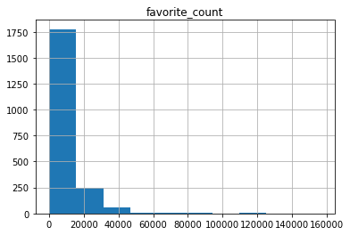

```python
df_fv_rt_images[["favorite_count"]].hist();
```

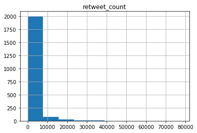

```python
df_fv_rt_images[["retweet_count"]].hist();
```

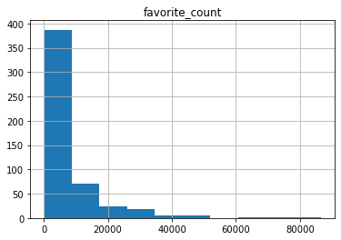

```python
df_fv_rt_images.loc[df_fv_rt_images.isdog == False,["favorite_count"]].hist();
```

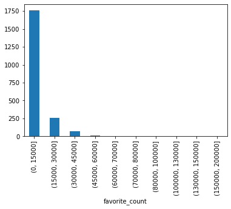

```python
bins = [0, 15000, 30000, 45000, 60000, 70000, 80000, 100000, 130000, 150000, 200000]
df_favs_binned = df_fv_rt_images.groupby(pd.cut(df_fv_rt_images.favorite_count, bins=bins)).favorite_count.count()
df_favs_binned.plot(kind='bar');
```

# Appendix

```python
%%javascript

// Sourced from http://nbviewer.jupyter.org/gist/minrk/5d0946d39d511d9e0b5a

$("#renumber-button").parent().remove();

function renumber() {
    // renumber cells in order
    var i=1;
    IPython.notebook.get_cells().map(function (cell) {
        if (cell.cell_type == 'code') {
            // set the input prompt
            cell.set_input_prompt(i);
            // set the output prompt (in two places)
            cell.output_area.outputs.map(function (output) {
                if (output.output_type == 'execute_result') {
                    output.execution_count = i;
                    cell.element.find(".output_prompt").text('Out[' + i + ']:');
                }
            });
            i += 1;
        }
    });
}

IPython.toolbar.add_buttons_group([{
  'label'   : 'Renumber',
  'icon'    : 'fa-list-ol',
  'callback': renumber,
  'id'      : 'renumber-button'
}]);
```

## Tweet examples downloaded via Tweepy API

The first entry, formatted by https://jsonformatter.curiousconcept.com/

[output not shown]

**An entry that is a retweet**

[output not shown]